# Modeling and Optimization

The Simplex Method and Duality Theory

Sebastian Souyris

MGMT 6460 Fall 2026

## Roadmap

1. **The Simplex Method.** Corners, basic solutions, pivots, the tableau
2. **LP Duality.** Bounds, weak and strong duality, complementary slackness
3. **Duality at Work.** Shadow prices, sensitivity, the dual simplex method, duals of other forms
4. Conclusions

# From Corners to an Algorithm

## Where We Left Off

- Lecture 01: an LP with an optimum has an optimal **corner** of the feasible region
- Wyndor has 5 corners: evaluate all of them
- A model with 50 variables and 50 constraints has up to $\binom{100}{50} \approx 10^{29}$ candidate corners

**The simplex method (Dantzig, 1947)**

Visit corners in a smart order, uphill only, and stop with a proof that no corner is better.

## Convex Sets

**Convex set**

A set $S$ is convex if the segment between any two of its points stays in $S$: for $\mathbf{u}, \mathbf{v} \in S$ and $0 \le \lambda \le 1$, $\;\lambda \mathbf{u} + (1 - \lambda)\mathbf{v} \in S$.

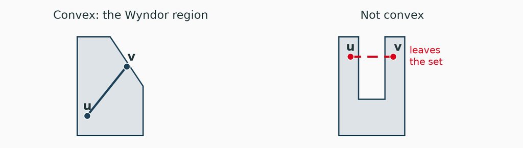

Each constraint keeps a half-plane, which is convex, and an intersection of convex sets is convex. So every LP’s feasible region is convex.

## The Simplex Method: Main Idea

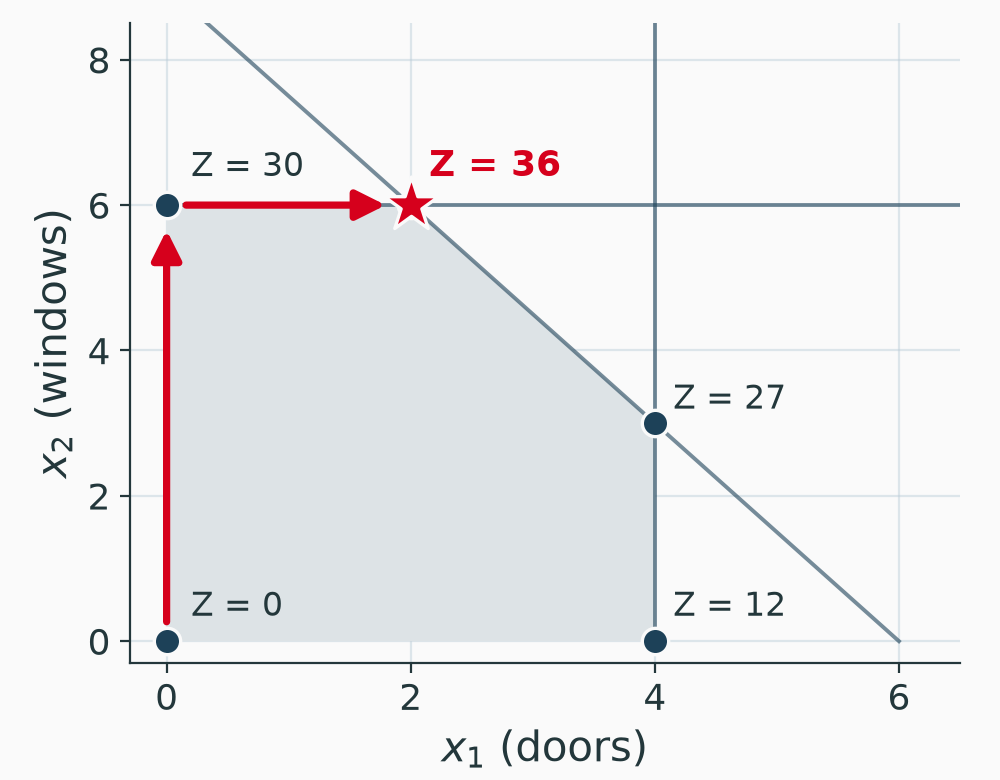

1. **Start** at a vertex: $(0, 0)$
2. **Test.** Is an adjacent vertex better?
3. **Move** along that edge. Repeat

**Optimality of a vertex**

The region is convex and $Z$ is linear. A vertex with no better neighbor beats every feasible point.

# Standard Form and Basic Solutions

## Standard Form

**Canonical form**

$$\begin{aligned}
\max~ Z = 3x_1 &+ 5x_2 \\
\text{s.t.} \quad x_1 \phantom{{}+2x_2} &\le 4 \\
2x_2 &\le 12 \\
3x_1 + 2x_2 &\le 18 \\
x_1, x_2 &\ge 0
\end{aligned}$$

**Standard form**

$$\begin{alignat*}{6}
\max~ Z ={} && 3x_1 & {}+{} & 5x_2 & & & & & & & \\
\text{s.t.} \quad && x_1 & & & {}+{} & x_3 & & & & & {}= 4 \\
&& & & 2x_2 & & & {}+{} & x_4 & & & {}= 12 \\
&& 3x_1 & {}+{} & 2x_2 & & & & & {}+{} & x_5 & {}= 18 \\
&& \rlap{x_1, \dots, x_5 \ge 0} & & & & & & & & &
\end{alignat*}$$

- Slack variables $x_3, x_4, x_5$: idle hours at Plants 1, 2, 3
- Each $\le$ becomes an equation: the standard form. A plan is feasible when all five variables are $\ge 0$

## Basic Solutions

Three equations, five variables. Set two nonbasic variables to 0 and solve for the three basic ones.

| Vertex | Nonbasic ($= 0$) | $(x_1, x_2, x_3, x_4, x_5)$ | Sits on |
| --- | --- | --- | --- |
| $(0, 0)$ | $x_1, x_2$ | $(0, 0, 4, 12, 18)$ | both axes |
| $(0, 6)$ | $x_1, x_4$ | $(0, 6, 4, 0, 6)$ | $x_1 = 0$, Plant 2 |
| $(2, 6)$ | $x_4, x_5$ | $(2, 6, 2, 0, 0)$ | Plants 2 and 3 |
| $(4, 3)$ | $x_3, x_5$ | $(4, 3, 0, 6, 0)$ | Plants 1 and 3 |
| $(4, 0)$ | $x_2, x_3$ | $(4, 0, 0, 12, 6)$ | $x_2 = 0$, Plant 1 |

**Basic feasible solution (BFS)**

A basic solution with every variable $\ge 0$. Each BFS is a vertex. Adjacent vertices differ by one swap: one variable **in**, one **out**.

## Basic Solutions on the Graph

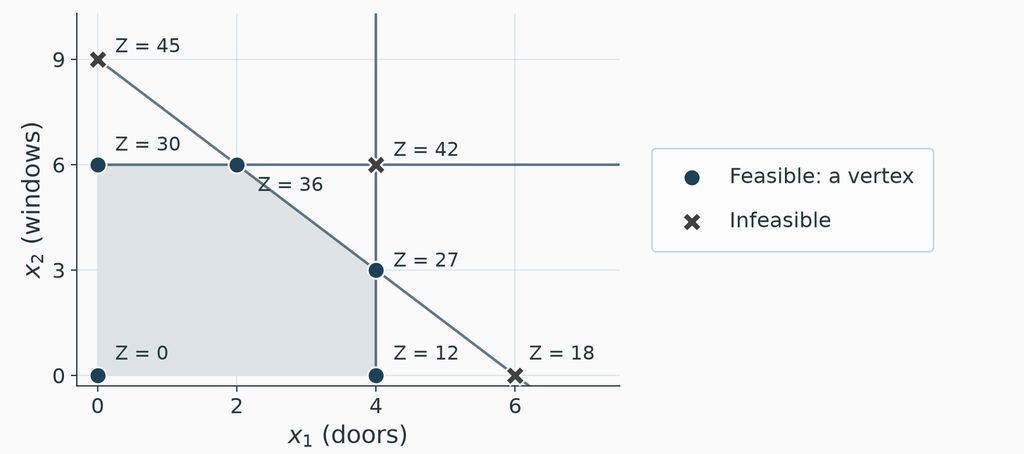

There are 10 ways to pick two nonbasic variables. Two give parallel lines ($x_1 = 0$ with $x_1 = 4$; $x_2 = 0$ with $x_2 = 6$) and no solution. The other 8 are basic solutions: 5 feasible, 3 not.

# Three Iterations on Wyndor

## Iteration 0: The Dictionary

$$\begin{aligned}
Z &= 0 + 3x_1 + 5x_2 \\
x_3 &= 4 - x_1 \\
x_4 &= 12 - 2x_2 \\
x_5 &= 18 - 3x_1 - 2x_2
\end{aligned}$$

- Basic variables on the left, nonbasic on the right
- Nonbasic $x_1 = x_2 = 0$: read off $(0, 0, 4, 12, 18)$ and $Z = 0$

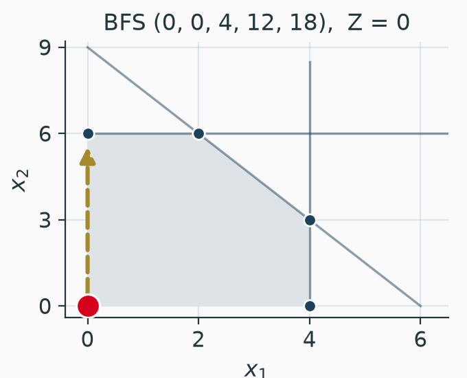

**Dictionary**

$Z$ and the basic variables written in terms of the nonbasic variables. Every iteration of simplex rewrites the dictionary for a new basis.

## Iteration 0: Who Enters?

$$Z = 0 + \textcolor{#D6001C}{3}x_1 + \textcolor{#D6001C}{5}x_2$$

**Reduced cost**

The coefficient of a nonbasic variable in the $Z$ row: what one more unit of it adds to $Z$. Written $\bar c_j$.

- $\bar c_1 = 3$: one batch of doors adds $3,000
- $\bar c_2 = 5$: one batch of windows adds $5,000
- Either one improves $Z$, so $(0, 0)$ is not optimal

**Entering rule**

The entering variable has the **largest positive reduced cost**: $x_2$.

## The Minimum Ratio Test

Hold $x_1 = 0$ and raise $x_2$. Every basic variable must stay $\ge 0$.

Only rows where $x_2$ pushes the basic variable down set a limit

| Row | As $x_2$ rises | Limit on $x_2$ |
| --- | --- | --- |
| $x_3 = 4 - x_1$ | $x_3 = 4$ | none |
| $x_4 = 12 - 2x_2$ | falls by 2 per unit | $12 / 2 = 6$ min |
| $x_5 = 18 - 3x_1 - 2x_2$ | falls by 2 per unit | $18 / 2 = 9$ |

**Leaving rule**

$x_4$ hits zero first: Plant 2 runs out of hours at $x_2 = 6$. The first resource to run out ends the step: its slack is the leaving variable.

## Pivoting

$x_2$ replaces $x_4$ in the basis. The pivot rewrites the dictionary.

1. Solve the leaving row for $x_2$: $\; x_2 = 6 - 0.5x_4$
2. Substitute into every other row, the $Z$ row included

$$\begin{aligned}
Z &= 30 + 3x_1 - 2.5x_4 \\
x_3 &= 4 - x_1 \\
x_2 &= 6 - 0.5x_4 \\
x_5 &= 6 - 3x_1 + x_4
\end{aligned}$$

- Nonbasic $x_1 = x_4 = 0$: the new BFS is $(0, 6, 4, 0, 6)$ with $Z = 30$
- A pivot is Gaussian elimination. The tableau, later, does the same arithmetic on the coefficients alone

## Iteration 1

$$\begin{aligned}
Z &= 30 + 3x_1 - 2.5x_4 \\
x_3 &= 4 - x_1 \\
x_2 &= 6 - 0.5x_4 \\
x_5 &= 6 - 3x_1 + x_4
\end{aligned}$$

- $\bar c_1 = 3 > 0$: $x_1$ enters
- Ratios: $x_3$ allows 4, $x_5$ allows 2 min, $x_2$ sets no limit

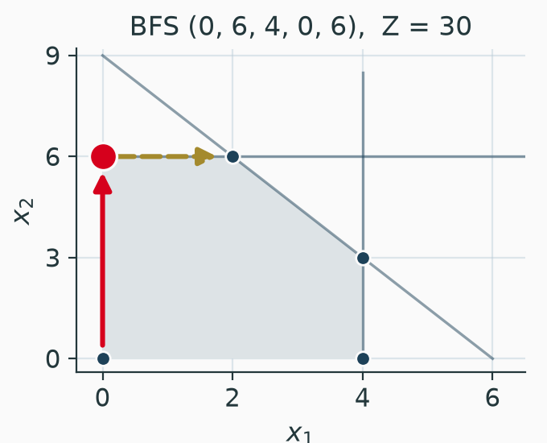

**Leaving variable**

$x_5$ leaves: Plant 3’s 6 idle hours allow 2 batches of doors.

## Iteration 2

$$\begin{aligned}
Z &= 36 - 1.5x_4 - x_5 \\
x_3 &= 2 - \tfrac{1}{3}x_4 + \tfrac{1}{3}x_5 \\
x_2 &= 6 - 0.5x_4 \\
x_1 &= 2 + \tfrac{1}{3}x_4 - \tfrac{1}{3}x_5
\end{aligned}$$

- Every reduced cost is $\le 0$
- $Z^* = 36$ at $(2, 6)$

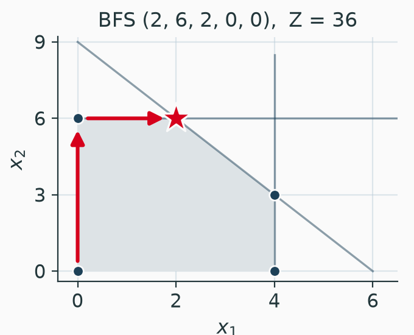

**Optimality test**

Stop when every reduced cost is $\le 0$. Here the only moves left idle Plant 2 or Plant 3 hours, and each lowers $Z$.

# The Simplex Tableau

## The Simplex Tableau

The tableau keeps only the coefficients. Iteration 0:

Pivot column $x_2$, pivot row (2) (minimum ratio), pivot number 2

| Basic | Eq. | $Z$ | $x_1$ | $x_2$ | $x_3$ | $x_4$ | $x_5$ | RHS | Ratio |
| --- | --- | --- | --- | --- | --- | --- | --- | --- | --- |
| $Z$ | (0) | 1 | −3 | −5 | 0 | 0 | 0 | 0 |  |
| $x_3$ | (1) | 0 | 1 | 0 | 1 | 0 | 0 | 4 | none |
| $x_4$ | (2) | 0 | 0 | 2 | 0 | 1 | 0 | 12 | 6 min |
| $x_5$ | (3) | 0 | 3 | 2 | 0 | 0 | 1 | 18 | 9 |

**Sign convention**

Row (0) is $Z - 3x_1 - 5x_2 = 0$: the objective moved to the left, so it holds the reduced costs **with their signs flipped**. Enter on the most negative row-(0) entry; stop when row (0) is $\ge 0$.

## The Simplex Tableau: Iterations 1 and 2

Iteration 1, at $(0, 6)$: $x_1$ enters, $x_5$ leaves

| Basic | Eq. | $Z$ | $x_1$ | $x_2$ | $x_3$ | $x_4$ | $x_5$ | RHS | Ratio |
| --- | --- | --- | --- | --- | --- | --- | --- | --- | --- |
| $Z$ | (0) | 1 | −3 | 0 | 0 | 2.5 | 0 | 30 |  |
| $x_3$ | (1) | 0 | 1 | 0 | 1 | 0 | 0 | 4 | 4 |
| $x_2$ | (2) | 0 | 0 | 1 | 0 | 0.5 | 0 | 6 | none |
| $x_5$ | (3) | 0 | 3 | 0 | 0 | −1 | 1 | 6 | 2 min |

Iteration 2, at $(2, 6)$: row (0) is $\ge 0$, so optimal. Compare the dictionary $Z = 36 - 1.5x_4 - x_5$

| Basic | Eq. | $Z$ | $x_1$ | $x_2$ | $x_3$ | $x_4$ | $x_5$ | RHS | Ratio |
| --- | --- | --- | --- | --- | --- | --- | --- | --- | --- |
| $Z$ | (0) | 1 | 0 | 0 | 0 | 1.5 | 1 | 36 |  |
| $x_3$ | (1) | 0 | 0 | 0 | 1 | 1/3 | −1/3 | 2 |  |
| $x_2$ | (2) | 0 | 0 | 1 | 0 | 0.5 | 0 | 6 |  |
| $x_1$ | (3) | 0 | 1 | 0 | 0 | −1/3 | 1/3 | 2 |  |

## Summary of the Simplex Method

**The simplex method**

1. **Initialize.** Add slacks. Start at the origin, with the slacks basic
2. **Test.** Stop if every reduced cost is $\le 0$ (row (0) $\ge 0$)
3. **Enter.** The largest reduced cost (most negative row-(0) entry) picks the pivot column
4. **Leave.** The minimum ratio test, over the **positive** entries of the pivot column, picks the pivot row
5. **Pivot.** Make the pivot number 1 and the rest of its column 0, row (0) included. Go to step 2

## Interactive: The Simplex Method

[interactive chart not shown]

# Special Cases

## Special Cases

| Situation | What you see | What it means |
| --- | --- | --- |
| Tie for entering | Two equal largest reduced costs | Pick either |
| Tie for leaving | Two equal minimum ratios; a basic variable drops to 0 | Degenerate. The next pivot may not raise $Z$ |
| No leaving variable | No positive entry in the pivot column | $Z$ is unbounded. Usually a missing constraint |
| Multiple optima | A nonbasic variable has reduced cost 0 at the optimum | Pivoting it in reaches another optimal corner |

**Cycling**

Degenerate pivots can, in theory, return to a basis already visited and cycle forever. Choosing the lowest index among tied candidates (Bland’s rule) prevents it.

## When the Origin Is Infeasible

The radiation therapy model of lecture 01 has an equation and a $\ge$ constraint:

$$0.5x_1 + 0.5x_2 = 6, \qquad 0.6x_1 + 0.4x_2 \ge 6$$

- $(0, 0)$ violates both, so there is no slack basis to start from
- **Phase I** adds an artificial variable to each such row and minimizes their sum. A sum of 0 gives a first BFS; a positive minimum proves the LP infeasible
- **Phase II** is the simplex method of this part, from that BFS

**In practice**

Gurobi and Excel Solver find a starting basis on their own. The model never needs artificial variables.

## Practice: Run the Simplex Method

**Practice Problem**

$$\max~ Z = 4x_1 + 3x_2 \quad \text{s.t.} \quad
x_1 + x_2 \le 4, \quad 2x_1 + x_2 \le 6, \quad x_1, x_2 \ge 0$$

1. Write the initial dictionary with slacks $x_3, x_4$.
2. Run the simplex method to the optimum.
3. Record the reduced costs of $x_3$ and $x_4$ at the optimum. Keep them for Part II.

**Check**

2. $x_1$ in, $x_4$ out: $(3, 0)$, $Z = 12$. Then $x_2$ in, $x_3$ out: $(2, 2)$, $Z = 14$. (c) Final $Z$ row: $Z = 14 - 2x_3 - x_4$, so $-2$ and $-1$. In the tableau, row (0) reads $Z + 2x_3 + x_4 = 14$.

## Part II: LP Duality

$Z = 36 - 1.5x_4 - x_5$. What are 1.5 and 1?

# Bounding the Optimum

## Is 36 the Best?

- Simplex found $(2, 6)$ with $Z = 36$. Any feasible plan gives a lower bound: $Z^* \ge 36$
- To show $Z^* \le 36$ we need an upper bound that holds for **every** feasible plan

**Idea.** Add up the plant constraints with weights $y_i \ge 0$, until the left side is at least $3x_1 + 5x_2$.

$$3x_1 + 5x_2 \;\le\; 7.5x_1 + 5x_2 \;=\; 2.5\,(3x_1 + 2x_2) \;\le\; 2.5 \cdot 18 = 45$$

- First step: $3x_1 \le 7.5x_1$ because $x_1 \ge 0$
- Last step: Plant 3’s constraint times $2.5 \ge 0$
- So **no** plan earns more than 45

## Three Bounds

Each row covers $3x_1$ and $5x_2$ on the left, so it bounds $Z$

| Weights $(y_1, y_2, y_3)$ | Sum of weighted constraints | Bound |
| --- | --- | --- |
| $(0, 0, 2.5)$ | $7.5x_1 + 5x_2 \le 45$ | $Z \le 45$ |
| $(3, 2.5, 0)$ | $3x_1 + 5x_2 \le 12 + 30 = 42$ | $Z \le 42$ |
| $(0, 1.5, 1)$ | $3x_1 + 5x_2 \le 18 + 18 = 36$ | $Z \le 36$ |

**A proof of optimality**

The third bound equals the profit of $(2, 6)$. No plan beats 36, so $(2, 6)$ is optimal, and no simplex run was needed to prove it.

## The Best Bound Is an LP

Weights $y_1, y_2, y_3 \ge 0$ on the three plants give

$$(y_1 + 3y_3)\,x_1 + (2y_2 + 2y_3)\,x_2 \;\le\; 4y_1 + 12y_2 + 18y_3$$

- The left side covers $3x_1 + 5x_2$ when $\;y_1 + 3y_3 \ge 3\;$ and $\;2y_2 + 2y_3 \ge 5$
- Then $Z \le W = 4y_1 + 12y_2 + 18y_3$

**The dual**

The smallest such bound solves $\;\min W = 4y_1 + 12y_2 + 18y_3\;$ s.t. $\;y_1 + 3y_3 \ge 3$, $\;2y_2 + 2y_3 \ge 5$, $\;y \ge 0$. This LP is the dual; the original is the primal.

## Wyndor: Primal and Dual

**Primal (lecture 01)**

$$\begin{aligned}
\max~ Z = 3x_1 &+ 5x_2 \\
\text{s.t.} \quad x_1 \phantom{{}+2x_2} &\le 4 && \textcolor{#D6001C}{(y_1)} \\
2x_2 &\le 12 && \textcolor{#D6001C}{(y_2)} \\
3x_1 + 2x_2 &\le 18 && \textcolor{#D6001C}{(y_3)} \\
x_1, x_2 &\ge 0
\end{aligned}$$

**Dual**

$$\begin{aligned}
\min~ W = 4y_1 + 12y_2 &+ 18y_3 \\
\text{s.t.} \quad y_1 \phantom{{}+2y_2} + 3y_3 &\ge 3 && \textcolor{#D6001C}{(x_1)} \\
2y_2 + 2y_3 &\ge 5 && \textcolor{#D6001C}{(x_2)} \\
y_1, y_2, y_3 &\ge 0
\end{aligned}$$

- One dual variable per primal constraint: $y_i$ belongs to Plant $i$
- One dual constraint per primal variable: row $j$ of the dual reads down column $j$ of the primal

# The Dual

## The Pair in Canonical Form

**Primal**

$$\begin{aligned}
\max~ Z &= \sum_{j=1}^{n} c_j x_j \\
\text{s.t.} \quad \sum_{j=1}^{n} a_{ij} x_j &\le b_i, \quad i = 1, \dots, m \\
x_j &\ge 0, \quad j = 1, \dots, n
\end{aligned}$$

**Dual**

$$\begin{aligned}
\min~ W &= \sum_{i=1}^{m} b_i y_i \\
\text{s.t.} \quad \sum_{i=1}^{m} a_{ij} y_i &\ge c_j, \quad j = 1, \dots, n \\
y_i &\ge 0, \quad i = 1, \dots, m
\end{aligned}$$

**Building the dual**

$\max$ becomes $\min$ and $\le$ becomes $\ge$. The vectors $b$ and $c$ trade places, and the matrix $A$ is **transposed**: rows of the primal are columns of the dual.

## Matrix Form

**Wyndor data**

$$\mathbf{c} = \begin{bmatrix} 3 & 5 \end{bmatrix}, \qquad
\mathbf{x} = \begin{bmatrix} x_1 \\ x_2 \end{bmatrix}$$

$$\mathbf{A} = \begin{bmatrix} 1 & 0 \\ 0 & 2 \\ 3 & 2 \end{bmatrix}, \qquad
\mathbf{b} = \begin{bmatrix} 4 \\ 12 \\ 18 \end{bmatrix}$$

$$\mathbf{y} = \begin{bmatrix} y_1 & y_2 & y_3 \end{bmatrix}$$

**Primal**

$$\max~ Z = \mathbf{cx} \quad \text{s.t.} \quad
\mathbf{Ax} \le \mathbf{b}, \;\; \mathbf{x} \ge \mathbf{0}$$

**Dual**

$$\min~ W = \mathbf{yb} \quad \text{s.t.} \quad
\mathbf{yA} \ge \mathbf{c}, \;\; \mathbf{y} \ge \mathbf{0}$$

- $\mathbf{x}$ is a column vector; $\mathbf{y}$ is a row vector
- This notation is used from here on

## The Economic Reading: Renting the Plants

A competitor offers to rent every Wyndor plant hour for a week, paying $y_i$ ($000) per hour at Plant $i$.

- **Wyndor’s condition.** Each product’s hours must rent for at least its profit. Doors: $y_1 + 3y_3 \ge 3$. Windows: $2y_2 + 2y_3 \ge 5$
- **Competitor’s goal.** Pay as little as possible: $\min W = 4y_1 + 12y_2 + 18y_3$

**Interpretation**

The lowest acceptable offer is $W^* = 36 = Z^*$: renting out the plants and producing are worth the same. $y^* = (0, 1.5, 1)$ is what an hour is worth at each plant.

## Practice: The Dual of the Practice Problem

**Practice Problem**

The Part I practice problem: $\;\max Z = 4x_1 + 3x_2\;$ s.t. $\;x_1 + x_2 \le 4$, $\;2x_1 + x_2 \le 6$, $\;x \ge 0$.

1. Write its dual.
2. Show that $\mathbf{y} = (2, 1)$ is dual feasible and find $W$.
3. What does (b) say about the plan $(2, 2)$ from Part I?

**Check**

1. $\min W = 4y_1 + 6y_2$ s.t. $y_1 + 2y_2 \ge 4$, $\;y_1 + y_2 \ge 3$, $\;y \ge 0$. (b) $4 \ge 4$ and $3 \ge 3$; $W = 14$. (c) $Z = 14$ at $(2, 2)$ equals the bound, so $(2, 2)$ is optimal.

# Weak and Strong Duality

## Weak Duality

**Weak duality property**

If $\mathbf{x}$ is feasible for the primal and $\mathbf{y}$ is feasible for the dual, then $\mathbf{cx} \le \mathbf{yb}$.

**Proof in one line.** Use $\mathbf{yA} \ge \mathbf{c}$ with $\mathbf{x} \ge \mathbf{0}$, then $\mathbf{Ax} \le \mathbf{b}$ with $\mathbf{y} \ge \mathbf{0}$:

$$\mathbf{cx} \;\le\; (\mathbf{yA})\mathbf{x} \;=\; \mathbf{y}(\mathbf{Ax})
\;\le\; \mathbf{yb}.$$

**Why it is useful**

Any dual feasible $\mathbf{y}$ is an upper bound on the best profit, and any feasible $\mathbf{x}$ is a lower bound on the least rent. The three bounds for Wyndor were this argument with numbers.

## Weak Duality: Illustration

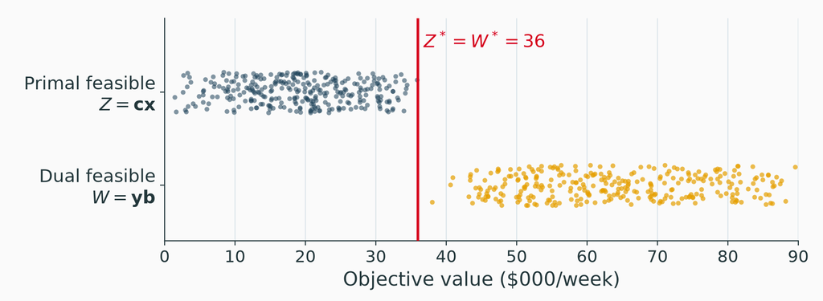

Every primal value sits left of 36. Every dual value sits right of it. The two sets meet only at 36.

## Strong Duality

**Strong duality property**

If the primal has an optimal solution $\mathbf{x}^*$, then the dual has an optimal solution $\mathbf{y}^*$, and $\mathbf{cx}^* = \mathbf{y}^*\mathbf{b}$.

- Weak duality says the best bound is at least $Z^*$
- Strong duality says some bound reaches $Z^*$ exactly: there is no gap
- The proof comes at the end of this part: simplex builds $\mathbf{y}^*$

**A certificate of optimality**

A feasible $\mathbf{x}$ and a feasible $\mathbf{y}$ with $\mathbf{cx} = \mathbf{yb}$ are **both optimal**. Anyone can check the claim with two substitutions and no solver.

## Practice: Check a Proposed Plan

**Practice Problem**

A consultant claims $(x_1, x_2) = (2, 6)$ is optimal for Wyndor. Verify the claim with $\mathbf{y} = (0, 1.5, 1)$ and no simplex iterations.

1. Is $(2, 6)$ primal feasible?
2. Is $(0, 1.5, 1)$ dual feasible?
3. Compare $Z$ and $W$. What do you conclude?

**Check**

1. $2 \le 4$, $12 \le 12$, $18 \le 18$. (b) $0 + 3 = 3 \ge 3$ and $3 + 2 = 5 \ge 5$. (c) $Z = W = 36$, so both are optimal.

## The Possible Outcomes

Only four pairings of outcomes can occur.

Possible outcomes for a primal-dual pair

|  | Dual has an optimum | Dual is unbounded | Dual is infeasible |
| --- | --- | --- | --- |
| **Primal has an optimum** | Possible, $Z^* = W^*$ | Never | Never |
| **Primal is unbounded** | Never | Never | Possible |
| **Primal is infeasible** | Never | Possible | Possible |

- An optimum on one side means an optimum on the other (strong duality)
- Unbounded on one side: the other side has no feasible solution (weak duality: nothing can bound it)

## The Dual of the Dual

| Step | Problem |
| --- | --- |
| 1. Start from the dual | $\min\ \mathbf{yb}$ s.t. $\mathbf{yA} \ge \mathbf{c}$, $\mathbf{y} \ge \mathbf{0}$ |
| 2. Rewrite in canonical form | $\max\ {-\mathbf{yb}}$ s.t. ${-\mathbf{yA}} \le {-\mathbf{c}}$, $\mathbf{y} \ge \mathbf{0}$ |
| 3. Take its dual | $\min\ {-\mathbf{cx}}$ s.t. ${-\mathbf{Ax}} \ge {-\mathbf{b}}$, $\mathbf{x} \ge \mathbf{0}$ |
| 4. Multiply by $-1$ | $\max\ \mathbf{cx}$ s.t. $\mathbf{Ax} \le \mathbf{b}$, $\mathbf{x} \ge \mathbf{0}$: the primal |

**Symmetry property**

The dual of the dual is the primal. Every relationship between a primal and its dual holds in both directions; which one is called “primal” is a label.

# Complementary Slackness

## The Price Identity

Take any plan $\mathbf{x}$ with idle hours $s_i = b_i - \sum_j a_{ij} x_j$, and any prices $\mathbf{y}$. Since $\mathbf{yb} - \mathbf{ys} = \mathbf{yAx}$:

$$\mathbf{cx} \;=\; \mathbf{yb} \;-\; \sum_i y_i\, s_i \;+\; \sum_j \bar c_j\, x_j,
\qquad \bar c_j = c_j - \sum_i a_{ij} y_i$$

- $\bar c_j$ is the reduced cost at prices $\mathbf{y}$: the profit of product $j$ minus the value of its hours
- Profit = value of all hours, minus the value of idle hours, plus what each product earns above the value of its hours

**The duality gap**

$\mathbf{yb} - \mathbf{cx} = \sum_i y_i s_i + \sum_j (-\bar c_j)\, x_j$. For a feasible pair every term is $\ge 0$: weak duality once more.

## Complementary Slackness

**Complementary slackness property**

A feasible $\mathbf{x}$ and a feasible $\mathbf{y}$ are both optimal if and only if, for every $i$ and $j$,
$$y_i\, s_i = 0 \qquad \text{and} \qquad \bar c_j\, x_j = 0.$$

- The gap is a sum of nonnegative terms, so it is 0 only when each term is 0
- **Idle capacity has price zero:** $s_i > 0 \Rightarrow y_i = 0$
- **A product made earns exactly the value of its hours:** $x_j > 0 \Rightarrow \bar c_j = 0$

## At the Wyndor Optimum

In every row at least one entry is zero

| Pair | Primal at $(2, 6)$ | Dual at $(0, 1.5, 1)$ |
| --- | --- | --- |
| Plant 1: $s_1$, $y_1$ | 2 idle hours | $y_1 = 0$ |
| Plant 2: $s_2$, $y_2$ | 0 idle hours | $y_2 = 1.5$ |
| Plant 3: $s_3$, $y_3$ | 0 idle hours | $y_3 = 1$ |
| Doors: $x_1$, $\bar c_1$ | $x_1 = 2$ | $\bar c_1 = 3 - (0 + 3 \cdot 1) = 0$ |
| Windows: $x_2$, $\bar c_2$ | $x_2 = 6$ | $\bar c_2 = 5 - (2 \cdot 1.5 + 2 \cdot 1) = 0$ |

**One direction only**

A binding constraint may still have price 0, and a product with $\bar c_j = 0$ may still be left out. The property rules out a pair of positive values and says nothing more.

## Finding $\mathbf{y}^*$ from $\mathbf{x}^*$

Given the optimal plan $(2, 6)$, complementary slackness writes the dual solution as equations:

1. Plant 1 is idle: $\;y_1 = 0$
2. Doors are made: $\;y_1 + 3y_3 = 3 \;\Rightarrow\; y_3 = 1$
3. Windows are made: $\;2y_2 + 2y_3 = 5 \;\Rightarrow\; y_2 = 1.5$

**Why this works**

Three equations, three unknowns, and no LP to solve. Check that the answer is dual feasible, then $W = 36 = Z$ confirms both.

## Practice: Prices from a Plan

**Practice Problem**

For the Part I practice problem the optimal plan is $(x_1, x_2) = (2, 2)$.

1. Which constraints are binding? Which products are made?
2. Use complementary slackness to find $\mathbf{y}^*$.
3. Compare with the reduced costs of $x_3, x_4$ you recorded in Part I.

**Check**

1. $2 + 2 = 4$ and $4 + 2 = 6$: both binding; both products made.
2. $y_1 + 2y_2 = 4$ and $y_1 + y_2 = 3$ give $\mathbf{y}^* = (2, 1)$, $W = 14$. (c) The reduced costs were $-2$ and $-1$: the prices with their signs flipped.

# Simplex Solves Both Problems

## The $Z$ Row Is the Price Identity

Wyndor’s final dictionary, next to the identity at $\mathbf{y} = (0, 1.5, 1)$:

$$\begin{aligned}
Z &= 36 \phantom{{}- 0x_3} - 1.5x_4 - 1x_5 \\
\mathbf{cx} &= \mathbf{yb} - y_1 x_3 - y_2 x_4 - y_3 x_5 + \bar c_1 x_1 + \bar c_2 x_2
\end{aligned}$$

The tableau’s row (0) holds the same numbers with signs flipped: $y_i$ under the slacks

| In the $Z$ row of a dictionary | Is |
| --- | --- |
| The constant | $W = \mathbf{yb}$ |
| Coefficient of slack $x_{n+i}$ | $-y_i$ |
| Coefficient of $x_j$ | $\bar c_j$ |

Simplex chooses $\mathbf{y}$ so that every **basic** variable has coefficient 0. That is complementary slackness, at every iteration.

## Prices at Every Iteration

$\bar c_j = c_j - \sum_i a_{ij} y_i$

| Iter. | $Z$ row of the dictionary | $\mathbf{y}$ | $\bar c_1$ | $\bar c_2$ | $W = Z$ | Dual feasible? |
| --- | --- | --- | --- | --- | --- | --- |
| 0 | $Z = 0 + 3x_1 + 5x_2$ | $(0, 0, 0)$ | 3 | 5 | 0 | No |
| 1 | $Z = 30 + 3x_1 - 2.5x_4$ | $(0, 2.5, 0)$ | 3 | 0 | 30 | No |
| 2 | $Z = 36 - 1.5x_4 - x_5$ | $(0, 1.5, 1)$ | 0 | 0 | 36 | Yes |

- Each iteration’s prices make the basic products break even
- At $(0, 6)$ the prices $(0, 2.5, 0)$ value a door’s hours at 0. It earns 3: underpriced, so doors enter

## Optimality Test and Dual Feasibility

| $Z$-row coefficient | In words | Dual constraint violated |
| --- | --- | --- |
| $\bar c_j > 0$ | Product $j$ earns more than its hours are worth | $\sum_i a_{ij} y_i \ge c_j$ |
| $-y_i > 0$ | Resource $i$ has a negative price | $y_i \ge 0$ |

**Optimality and dual feasibility**

Every $Z$-row coefficient is $\le 0$ **if and only if** the prices $\mathbf{y}$ are dual feasible. The simplex optimality test is a dual feasibility test.

## Simplex Proves Strong Duality

| Iter. | $Z{=}W$ | Primal feasible | Dual feasible |
| --- | --- | --- | --- |
| 0 | 0 | Yes | No |
| 1 | 30 | Yes | No |
| 2 | 36 | Yes | Yes |

1. Every iteration keeps $\mathbf{x}$ feasible and $Z = W$
2. Simplex stops (with Bland’s rule, always) when $\mathbf{y}$ is dual feasible
3. Now a feasible pair has $\mathbf{cx} = \mathbf{yb}$: both optimal

**Primal simplex, in one line**

Keep the plan feasible and the gap at zero; move until the prices become feasible. Part III runs the mirror image: the dual simplex method.

## Part III: Duality at Work

What is an hour worth, and what changes when the data change?

# Shadow Prices

## Wyndor’s Shadow Prices

**Shadow price**

The shadow price of resource $i$ is the rate at which $Z^*$ changes with $b_i$. It equals the optimal dual value $y_i^*$.

| Plant | Hours used | Available | Idle | Shadow price |
| --- | --- | --- | --- | --- |
| Plant 1 | 2 | 4 | 2 | $0 |
| Plant 2 | 12 | 12 | 0 | $1,500 / h |
| Plant 3 | 18 | 18 | 0 | $1,000 / h |

- Plant 1 has idle hours: one more is worth $0
- One more hour at Plant 2 adds $1,500 a week: pay up to that for overtime

## Shadow Prices as Slopes

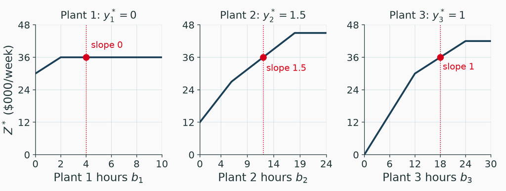

$Z^*$ is piecewise linear in each $b_i$. Its slope at today’s capacity is $y_i^*$. The slope holds only over a range: 6 to 18 hours at Plant 2.

## Interactive: Changing Plant Capacity

[interactive chart not shown]

## Reading Dual Prices from a Solver

```python
m.optimize()
for c in m.getConstrs():
    print(c.ConstrName, c.Pi,
          c.SARHSLow, c.SARHSUp)
for v in m.getVars():
    print(v.VarName, v.RC,
          v.SAObjLow, v.SAObjUp)

# plant1     0.0  2.0  inf
# plant2     1.5  6.0  18.0
# plant3     1.0  12.0 24.0
# x[doors]   0.0  0.0  7.5
# x[windows] 0.0  2.0  inf
```

- `Pi`: the dual value $y_i^*$
- `SARHSLow`, `SARHSUp`: the range of $b_i$ where it holds
- `RC`: the reduced cost $\bar c_j$
- `SAObjLow`, `SAObjUp`: the range of $c_j$ where the plan stays optimal
- Colab: [wyndor_dual_prices.ipynb](https://colab.research.google.com/drive/1k8b0KOxNK0j39SsZNgEfUcnh4sxr8zZD)

**Excel Solver**

Ask for the **Sensitivity Report**. *Shadow Price* is $y_i^*$ and *Reduced Cost* is $\bar c_j$, with the same signs as Gurobi. The *Allowable Increase* and *Decrease* columns give the same ranges.

# Sensitivity Analysis

## Changing a Profit

$(2, 6)$ stays optimal while the profit line’s slope $-c_1/c_2$ lies between the slopes of the two binding constraints:

- Plant 2, $2x_2 = 12$: slope 0
- Plant 3, $3x_1 + 2x_2 = 18$: slope $-3/2$

| Coefficient | Holding the other at | Range where $(2, 6)$ stays optimal |
| --- | --- | --- |
| Doors $c_1$ | $c_2 = 5$ | $0 \le c_1 \le 7.5$ |
| Windows $c_2$ | $c_1 = 3$ | $c_2 \ge 2$ |

**Inside and outside the range**

Inside, the plan stays and $Z^*$ moves by $x_j^*$ per unit of $c_j$; the shadow prices do change. Past $c_1 = 7.5$ the optimum moves to $(4, 3)$.

## Pricing Out a New Product

Wyndor considers **Product 3**: $4,000 per batch, using 0, 1 and 2 hours at Plants 1, 2, 3. Is the current plan still optimal?

**Value of its hours at $\mathbf{y}^* = (0, 1.5, 1)$.** $\;0(0) + 1(1.5) + 2(1) = 3.5$

**Reduced cost.** $\;\bar c_{\text{new}} = 4 - 3.5 = 0.5 > 0$: the new dual constraint $y_2 + 2y_3 \ge 4$ is violated.

**Interpretation**

At current shadow prices its hours cost $3,500 and it earns $4,000, so $(2, 6)$ is no longer optimal. Re-solving gives $Z^* = 39$ with $(x_1, x_2, x_{\text{new}}) = (0, 3, 6)$.

## Practice: Price Out Product 4

**Practice Problem**

Product 4 uses 1, 1 and 3 hours per batch at Plants 1, 2 and 3.

1. Write its dual constraint.
2. Is it worth making at a profit of $4,000 per batch? At $6,000?
3. What is the lowest profit that makes it worth adding?

**Check**

1. $y_1 + y_2 + 3y_3 \ge c_4$. (b) The hours are worth $0 + 1.5 + 3 = 4.5$. At $4,000, $\bar c_4 = -0.5$: no. At $6,000, $\bar c_4 = 1.5$: yes. (c) Anything above $4,500.

# The Dual Simplex Method

## A New Constraint

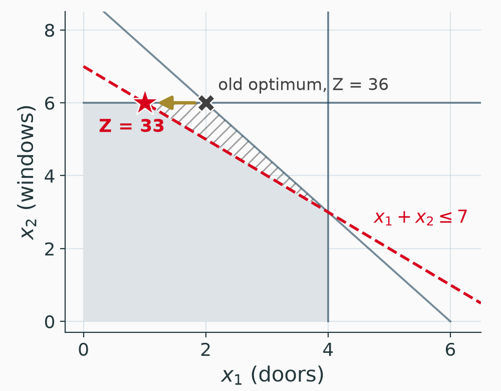

Assembly now caps output at 7 batches a week: $x_1 + x_2 \le 7$.

- $(2, 6)$ uses 8: **infeasible**
- The prices $(0, 1.5, 1)$ are still dual feasible: the $Z$ row did not change
- Start from the old optimum, and move toward feasibility

## The New Row

Add slack $x_6$ and write it in the final dictionary’s nonbasic variables, using $x_1 = 2 + \tfrac13 x_4 - \tfrac13 x_5$ and $x_2 = 6 - 0.5x_4$:

$$x_6 = 7 - x_1 - x_2 = -1 + \tfrac{1}{6}x_4 + \tfrac{1}{3}x_5$$

$$\begin{aligned}
Z &= 36 - 1.5x_4 - x_5 \\
x_3 &= 2 - \tfrac{1}{3}x_4 + \tfrac{1}{3}x_5 \\
x_2 &= 6 - 0.5x_4 \\
x_1 &= 2 + \tfrac{1}{3}x_4 - \tfrac{1}{3}x_5 \\
x_6 &= \textcolor{#D6001C}{-1} + \tfrac{1}{6}x_4 + \tfrac{1}{3}x_5
\end{aligned}$$

- **Primal infeasible:** $x_6 = -1$
- **Dual feasible:** every reduced cost is still $\le 0$
- The primal simplex method needs the opposite

## The Dual Simplex Pivot

**Dual simplex rules**

1. **Leave.** A basic variable with a negative value: $x_6$
2. **Enter.** Among the nonbasic variables that raise $x_6$, the one whose reduced cost is used up first: the smallest $|\bar c_j| / \text{rate}$
3. **Pivot** as usual. Stop when every basic variable is $\ge 0$

$x_5$ enters, $x_6$ leaves. The ratio test keeps every reduced cost $\le 0$

| Nonbasic | Reduced cost | Rate in $x_6$ row | Ratio |
| --- | --- | --- | --- |
| $x_4$ | $-1.5$ | $1/6$ | $1.5 / (1/6) = 9$ |
| $x_5$ | $-1$ | $1/3$ | $1 / (1/3) = 3$ min |

## After One Pivot

Solve the $x_6$ row for $x_5$, $\;x_5 = 3 - 0.5x_4 + 3x_6$, and substitute:

$$\begin{aligned}
Z &= 33 - x_4 - 3x_6 \\
x_3 &= 3 - 0.5x_4 + x_6 \\
x_2 &= 6 - 0.5x_4 \\
x_1 &= 1 + 0.5x_4 - x_6 \\
x_5 &= 3 - 0.5x_4 + 3x_6
\end{aligned}$$

- Every basic variable is $\ge 0$ and every reduced cost is $\le 0$: **optimal**
- $(x_1, x_2) = (1, 6)$, $\;Z^* = 33$
- New prices $\mathbf{y} = (0, 1, 0, 3)$

**Interpretation**

Assembly is now the bottleneck: one more assembly batch is worth $3,000, and Plant 3, with 3 idle hours, drops to $0.

## The Dual Simplex in the Tableau

Pivot row: the negative RHS. Pivot column: minimum of row (0) $\div$ |entry|, over **negative** entries of the pivot row

| Basic | $x_1$ | $x_2$ | $x_3$ | $x_4$ | $x_5$ | $x_6$ | RHS |
| --- | --- | --- | --- | --- | --- | --- | --- |
| $Z$ | 0 | 0 | 0 | 1.5 | 1 | 0 | 36 |
| $x_3$ | 0 | 0 | 1 | 1/3 | −1/3 | 0 | 2 |
| $x_2$ | 0 | 1 | 0 | 0.5 | 0 | 0 | 6 |
| $x_1$ | 1 | 0 | 0 | −1/3 | 1/3 | 0 | 2 |
| $x_6$ | 0 | 0 | 0 | −1/6 | −1/3 | 1 | −1 |
| Ratio |  |  |  | 9 | 3 min |  |  |

After the pivot: RHS $\ge 0$ and row (0) $\ge 0$, so optimal

| Basic | $x_1$ | $x_2$ | $x_3$ | $x_4$ | $x_5$ | $x_6$ | RHS |
| --- | --- | --- | --- | --- | --- | --- | --- |
| $Z$ | 0 | 0 | 0 | 1 | 0 | 3 | 33 |
| $x_3$ | 0 | 0 | 1 | 0.5 | 0 | −1 | 3 |
| $x_2$ | 0 | 1 | 0 | 0.5 | 0 | 0 | 6 |
| $x_1$ | 1 | 0 | 0 | −0.5 | 0 | 1 | 1 |
| $x_5$ | 0 | 0 | 0 | 0.5 | 1 | −3 | 3 |

## Primal and Dual Simplex

|  | Primal simplex | Dual simplex |
| --- | --- | --- |
| Keeps | Plan feasible (RHS $\ge 0$) | Prices feasible (row (0) $\ge 0$) |
| Chooses first | Entering variable, from row (0) | Leaving variable, from the RHS |
| Ratio test over | Positive entries of the pivot column | Negative entries of the pivot row |
| $Z$ along the way | Rises to $Z^*$ | Falls to $Z^*$, from above |
| Natural use | Solve from a feasible start | Re-solve after adding a constraint or cutting a $b_i$ |

**Where solvers use it**

Branch and bound (lecture 02) adds a bound such as $x_1 \le 2$ to an LP it has already solved. The old basis stays dual feasible, so the dual simplex method re-solves each branch in a few pivots.

## Practice: A Cap on Windows

**Practice Problem**

Instead of the assembly cap, the market takes at most 5 batches of windows: $x_2 \le 5$, with slack $x_6$.

1. Write $x_6$ in terms of $x_4$ and $x_5$ from the final dictionary.
2. Run one dual simplex pivot.
3. Report the plan, $Z^*$ and the new prices.

**Check**

1. $x_6 = -1 + 0.5x_4$. (b) Only $x_4$ raises $x_6$: it enters, ratio $1.5 / 0.5 = 3$. (c) $(8/3, 5)$, $Z^* = 33$ (so $Z = 33 - x_5 - 3x_6$), $\mathbf{y} = (0, 0, 1, 3)$.

# Duals of Other Forms

## The Primal-Dual Correspondence

Read left to right for a min primal, right to left for a max primal

| Primal: minimize | Dual: maximize |
| --- | --- |
| Constraint $i$: $\ge b_i$ | $y_i \ge 0$ |
| Constraint $i$: $\le b_i$ | $y_i \le 0$ |
| Constraint $i$: $= b_i$ | $y_i$ free |
| $x_j \ge 0$ | Constraint $j$: $\le c_j$ |
| $x_j \le 0$ | Constraint $j$: $\ge c_j$ |
| $x_j$ free | Constraint $j$: $= c_j$ |

Each constraint gives a dual variable; each variable gives a dual constraint. An equation always pairs with a free variable.

## Example: The Radiation Therapy Dual

**Primal (lecture 01), a min**

$$\begin{aligned}
\min~ Z = 0.4x_1 &+ 0.5x_2 \\
\text{s.t.} \quad 0.3x_1 + 0.1x_2 &\le 2.7 && (y_1) \\
0.5x_1 + 0.5x_2 &= 6 && (y_2) \\
0.6x_1 + 0.4x_2 &\ge 6 && (y_3) \\
x_1, x_2 &\ge 0
\end{aligned}$$

**Dual, a max**

$$\begin{aligned}
\max~ W = 2.7y_1 + 6y_2 &+ 6y_3 \\
\text{s.t.} \quad 0.3y_1 + 0.5y_2 + 0.6y_3 &\le 0.4 \\
0.1y_1 + 0.5y_2 + 0.4y_3 &\le 0.5 \\
y_1 \le 0, \;\; y_2 \text{ free}, \;\; y_3 &\ge 0
\end{aligned}$$

**Dual optimum**

$\mathbf{y}^* = (-0.5,\; 1.1,\; 0)$ and $W^* = 5.25 = Z^*$. A looser limit on healthy anatomy saves 0.5 per unit; a higher required tumor dose costs 1.1 per unit; the third constraint is slack, so its price is 0.

## Practice: Dual of a Mixed LP

**Practice Problem**

Write the dual of

$$\begin{aligned}
\max~ Z = 4x_1 &+ 3x_2 \\
\text{s.t.} \quad x_1 + 2x_2 &\le 10 \\
2x_1 + x_2 &\ge 4 \\
x_1 - x_2 &= 1 \\
x_1 \ge 0, \;\; &x_2 \text{ free}
\end{aligned}$$

**Check**

$\min\, W = 10y_1 + 4y_2 + y_3$ s.t. $y_1 + 2y_2 + y_3 \ge 4$, $\;2y_1 + y_2 - y_3 = 3$, $\;y_1 \ge 0$, $y_2 \le 0$, $y_3$ free. Both optima equal 25.

# Conclusions

## Why Duality Is Useful

1. **Certify a plan.** A dual feasible $\mathbf{y}$ with the same objective proves optimality, with no solver
2. **Price resources.** Shadow prices value capacity, labor and budget, over a stated range
3. **Test changes cheaply.** A new product is one dual constraint; a new constraint is a few dual simplex pivots
4. **Solve the easier problem.** A model with many more constraints than variables can be faster to solve through its dual

## Summary

**Core takeaways**

- Simplex walks uphill from vertex to adjacent vertex and stops when every reduced cost is $\le 0$
- The dual is the best bound from weighted constraints
- $\mathbf{cx} \le \mathbf{yb}$ for any feasible pair; $Z^* = W^*$ at the optimum
- Complementary slackness: idle resources are free; products made break even
- Reduced costs $\le 0$ $\iff$ $\mathbf{y}$ dual feasible
- $y_i^*$ = slope of $Z^*$ in $b_i$

**Watch out for**

- The tableau’s row (0) holds reduced costs with signs flipped
- Ratio tests: positive column entries (primal), negative row entries (dual)
- Shadow prices hold only within the allowable range
- A binding constraint can still have price 0
- Nonunique prices at breakpoints

**Bottom line**

The primal says what to do. The dual says what each resource is worth.

## Questions?

The Simplex Method and Duality Theory

MGMT 6460

# Appendix

## Appendix: References

**Textbooks**  
Vanderbei, R. J. *Linear Programming: Foundations and Extensions*, 5th ed. Springer, 2020. [doi:10.1007/978-3-030-39415-8](https://doi.org/10.1007/978-3-030-39415-8). The dictionary form of simplex and the bound derivation of the dual.

Bertsimas, D. and Tsitsiklis, J. N. *Introduction to Linear Optimization*. Athena Scientific, 1997. Standard form, basic feasible solutions, reduced costs, the primal-dual correspondence.

**Articles**  
Lemke, C. E. The dual method of solving the linear programming problem. *Naval Research Logistics Quarterly* 1(1), 36–47, 1954. [doi:10.1002/nav.3800010107](https://doi.org/10.1002/nav.3800010107)

Bland, R. G. New finite pivoting rules for the simplex method. *Mathematics of Operations Research* 2(2), 103–107, 1977. [doi:10.1287/moor.2.2.103](https://doi.org/10.1287/moor.2.2.103)

**Software**  
Gurobi attributes `Pi`, `RC`, `SARHSLow`, `SARHSUp`, `SAObjLow`, `SAObjUp`: [docs.gurobi.com](https://docs.gurobi.com/projects/optimizer/en/current/reference/attributes.html)